# Week 2 Study Guide

Eric Schmidt

2026-11-25

# Chapter 3: Descriptive Statistics.

## 3.0 Overview & Core Descriptive Framework

- **Learning Objectives:**
  1. Calculate and interpret measures of central tendency — arithmetic mean, median, mode, percentiles, and quartiles — for ungrouped business data.
  2. Compute and contrast measures of variability — range, interquartile range ($IQR$), mean absolute deviation (MAD), variance, standard deviation, and coefficient of variation ($CV$).
  3. Differentiate between sample statistics ($s^2, s$) using Bessel’s correction ($n-1$) and population parameters ($\sigma^2, \sigma$).
  4. Apply Chebyshev’s Theorem and the Empirical Rule to assess data spread relative to the mean and standard deviation.
  5. Compute the mean, median, mode, variance, and standard deviation for grouped data using class intervals and midpoints.
  6. Characterize distribution shape using skewness, kurtosis, kernel density estimators, and box-and-whisker plots with Tukey’s outlier fences.
  7. Apply modern robust descriptive statistics (trimmed means, Winsorized variance) and recognize the masking problem inherent in classical outlier detection rules (Wilcox Ch. 2).
  8. Quantify bivariate linear association using covariance and Pearson’s product-moment correlation coefficient ($r$).
- **Four Core Dimensions of Descriptive Analytics:**
  - **Central Tendency:** The center, typical value, or gravitational balance point of a numeric distribution (Mean, Median, Mode, Trimmed Mean).
  - **Variability (Dispersion):** The spread, scatter, or distance of individual observations around the central value (Range, $IQR$, Variance, Standard Deviation, $CV$, Winsorized Variance).
  - **Distribution Shape & Relative Position:** The symmetry, skewness, kurtosis, percentile ranks, and presence of extreme outliers (Five-Number Summary, Tukey’s Fences, Boxplots, Kernel Density Estimation).
  - **Bivariate Association:** The strength and direction of linear co-movement between two continuous variables (Covariance, Pearson’s Correlation Coefficient $r$).

## 3.1 Measures of Central Tendency: Ungrouped Data

Measures of central tendency identify the center or typical value of a numerical distribution.

- **Arithmetic Mean:** The arithmetic balance point of a dataset, computed by summing all values and dividing by the total count. Highly sensitive to extreme outliers.
  - **Population Mean ($\mu$):**

$$\mu = \frac{\sum_{i=1}^N
x_i}{N}$$

- **Sample Mean ($\bar{x}$):**

$$\bar{x} = \frac{\sum_{i=1}^n
x_i}{n}$$

- **Median:** The middle value in an ordered (ranked) array of data ($x_{(1)} \le x_{(2)} \le \dots \le x_{(n)}$). Resistant and robust against extreme values.
  - If $n$ is odd, the median is the value at position $\frac{n+1}{2}$.
  - If $n$ is even, the median is the arithmetic average of the values at positions $\frac{n}{2}$ and $\frac{n}{2} + 1$:

$$\text{Median} = \frac{x_{(n/2)} +
x_{(n/2 + 1)}}{2}$$

- **Mode:** The value that occurs with greatest frequency. Applicable to nominal, ordinal, interval, and ratio data. A dataset may be unimodal (one mode), bimodal (two modes), multimodal (multiple modes), or possess no mode if all observations are distinct.
- **Percentiles and Quartiles:**
  - **Percentiles ($P$):** Divides ordered data into 100 equal parts. The location  
    index $i$ for the $P$-th percentile is shown in the following formula.
    - If $i$ is not an integer, round up to the next integer.
    - If $i$ is an integer, average the value at location $i$ and location $i+1$.

$$i = \left(\frac{P}{100}\right) \cdot
n$$

- **Quartiles:** Divides ordered data into four equal parts:
  - **First Quartile ($Q_1$):** 25th percentile ($P_{25}$).
  - **Second Quartile ($Q_2$):** 50th percentile (Median, $P_{50}$).
  - **Third Quartile ($Q_3$):** 75th percentile ($P_{75}$).
- **Modern Robust Location Measures (Wilcox Ch. 2):**
  - **The 20% Trimmed Mean ($\bar{x}_t$):** While the sample mean represents zero trimming (excessively sensitive to outliers) and the median represents maximum trimming (discarding all but 1 or 2 values), the trimmed mean offers a robust compromise. For sample size $n$, compute $g = \lfloor 0.2n \rfloor$ (rounded down to the nearest integer), trim the $g$ smallest and $g$ largest values, and compute the arithmetic average of the remaining $n - 2g$ observations:

$$\bar{x}_t = \frac{\sum_{i=g+1}^{n-g}
x_{(i)}}{n - 2g}$$

```r
shop_sizes <- c(190.0, 180.9, 175.0, 155.7, 154.0, 149.5, 140.8,
                139.4, 139.4, 133.8, 130.1, 127.1, 125.4)

skating <- c(5.1, 5.3, 5.3, 5.5, 5.0, 5.1, 5.4, 4.2, 5.2)

calc_mode <- function(x) {
  tbl <- table(x)
  modes <- names(tbl)[tbl == max(tbl)]
  as.numeric(modes)[1]
}

manual_mean <- sum(shop_sizes) / length(shop_sizes)
skating_sorted <- sort(skating)
g_skate <- floor(0.2 * length(skating))
manual_trim_skate <- sum(skating_sorted[(g_skate + 1):(length(skating) - g_skate)]) / (length(skating) - 2 * g_skate)

even_sample <- c(10, 14, 18, 22, 26, 30)
n_even <- length(even_sample)
even_sorted <- sort(even_sample)
manual_even_median <- (even_sorted[n_even / 2] + even_sorted[n_even / 2 + 1]) / 2

p25_idx <- (25 / 100) * length(shop_sizes)
p25_manual <- sort(shop_sizes)[ceiling(p25_idx)]
print(sprintf("Demo 3.1 sum/n = %.2f | P25 index = %.2f -> Q1 = %.2f",
              manual_mean, p25_idx, p25_manual))
```

```
## [1] "Demo 3.1 sum/n = 149.32 | P25 index = 3.25 -> Q1 = 133.80"
```

```r
print(sprintf("Wilcox skating g = %d | manual 20%% trimmed mean = %.2f | Even median check = %.1f",
              g_skate, manual_trim_skate, manual_even_median))
```

```
## [1] "Wilcox skating g = 1 | manual 20% trimmed mean = 5.20 | Even median check = 20.0"
```

```r
central_summary <- data.frame(
  Dataset = c("UK Shopping Centres", "Figure Skating Ratings"),
  n = c(length(shop_sizes), length(skating)),
  Mean = round(c(mean(shop_sizes), mean(skating)), 2),
  Median = round(c(median(shop_sizes), median(skating)), 2),
  Trimmed_20 = round(c(mean(shop_sizes, trim = 0.2), mean(skating, trim = 0.2)), 2),
  Mode = c(calc_mode(shop_sizes), calc_mode(skating)),
  Q1 = round(c(quantile(shop_sizes, 0.25, type = 6), quantile(skating, 0.25, type = 6)), 2),
  Q3 = round(c(quantile(shop_sizes, 0.75, type = 6), quantile(skating, 0.75, type = 6)), 2)
)

print(central_summary)
```

```
##                  Dataset  n   Mean Median Trimmed_20  Mode     Q1     Q3
## 1    UK Shopping Centres 13 149.32  140.8     146.41 139.4 131.95 165.35
## 2 Figure Skating Ratings  9   5.12    5.2       5.20   5.1   5.05   5.35
```

## 3.2 Measures of Variability: Ungrouped Data

Measures of variability quantify the dispersion, scatter, or spread of data values around their central location.

- **Range & Interquartile Range ($IQR$):**
  - **Range:** Difference between the highest and lowest values:

$$\text{Range} = x_{\text{max}} -
x_{\text{min}}$$

- **Interquartile Range ($IQR$):** Spread of the middle 50% of ordered observations:

$$IQR = Q_3 - Q_1$$

- **Population vs. Sample Variance and Standard Deviation:**
  - **Mean Absolute Deviation (MAD):** Average absolute deviation from the mean:

$$\text{MAD} = \frac{\sum_{i=1}^n |x_i -
\bar{x}|}{n}$$

- **Population Variance ($\sigma^2$):**

$$\sigma^2 = \frac{\sum_{i=1}^N (x_i -
\mu)^2}{N}$$

- **Sample Variance ($s^2$):** Uses degrees of freedom ($n - 1$, Bessel’s correction) as an unbiased estimator of $\sigma^2$:

$$s^2 = \frac{\sum_{i=1}^n (x_i -
\bar{x})^2}{n - 1} = \frac{\sum x_i^2 - \frac{(\sum x_i)^2}{n}}{n -
1}$$

- **Standard Deviation:** Positive square root of variance, restoring original units of measurement:

$$\sigma = \sqrt{\sigma^2}, \quad s =
\sqrt{s^2}$$

- **Coefficient of Variation ($CV$):** A unitless measure of relative variability expressed as a percentage of the mean:

$$CV = \left(\frac{s}{\bar{x}}\right)
\times 100\% \quad \text{or} \quad \left(\frac{\sigma}{\mu}\right)
\times 100\%$$

- **Interpreting Standard Deviation: Chebyshev’s Theorem vs. The Empirical Rule:**
  - **Chebyshev’s Theorem (Any Distribution):** For any dataset regardless of shape, and any constant $k > 1$, the proportion of values that fall within $k$ standard deviations of the mean ($\mu \pm k\sigma$) is at least:

$$1 - \frac{1}{k^2}$$

```
- For $k = 2$: At least $1 - \frac{1}{4} = 75\%$ of values lie within $\mu \pm 2\sigma$.
- For $k = 3$: At least $1 - \frac{1}{9} \approx 88.89\%$ of values lie within $\mu \pm 3\sigma$.
```

- **The Empirical Rule (Mound-Shaped / Bell-Shaped Normal Distributions):**
  - Approximately **$68\%$** of data points fall within $\mu \pm 1\sigma$.
  - Approximately **$95\%$** of data points fall within $\mu \pm 2\sigma$.
  - Approximately **$99.7\%$** of data points fall within $\mu \pm 3\sigma$.
- **Modern Robust Dispersion: The 20% Winsorized Variance ($s_w^2$):**
  - Instead of trimming extreme observations completely, Winsorizing replaces the $g = \lfloor 0.2n \rfloor$ smallest values with $x_{(g+1)}$ and the $g$ largest values with $x_{(n-g)}$. The Winsorized sample variance ($s_w^2$) is computed across the transformed array $W_1, \dots, W_n$:

$$s_w^2 = \frac{\sum_{i=1}^n (W_i -
\bar{W})^2}{n - 1}$$

Unlike the classical sample variance $s^2$, $s_w^2$ does not artificially balloon when an outlier shifts farther into the extreme tails, providing a stable foundation for robust inferential procedures.

```r
top_15_exports <- c(312.4, 240.2, 123.7, 66.8, 53.8, 49.4, 44.5,
                    43.1, 42.4, 40.9, 34.8, 31.3, 30.2, 26.7, 22.2)

acc_partners <- c(88, 75, 45, 37, 24, 21)

calc_winsorized_var <- function(x, tr = 0.2) {
  n <- length(x)
  g <- floor(tr * n)
  x_sort <- sort(x)
  w <- x_sort
  if (g > 0) {
    w[1:g] <- x_sort[g + 1]
    w[(n - g + 1):n] <- x_sort[n - g]
  }
  var(w)
}

pop_var <- function(x) {
  sum((x - mean(x))^2) / length(x)
}

dispersion_summary <- data.frame(
  Dataset = c("Top 15 US Exports ($B)", "Accounting Firm Partners"),
  Mean = round(c(mean(top_15_exports), mean(acc_partners)), 2),
  Range = round(c(diff(range(top_15_exports)), diff(range(acc_partners))), 2),
  IQR = round(c(quantile(top_15_exports, 0.75, type = 6) - quantile(top_15_exports, 0.25, type = 6),
                quantile(acc_partners, 0.75, type = 6) - quantile(acc_partners, 0.25, type = 6)), 2),
  MAD = round(c(sum(abs(top_15_exports - mean(top_15_exports))) / length(top_15_exports),
                sum(abs(acc_partners - mean(acc_partners))) / length(acc_partners)), 2),
  Pop_Variance = round(c(pop_var(top_15_exports), pop_var(acc_partners)), 2),
  Sample_Variance = round(c(var(top_15_exports), var(acc_partners)), 2),
  Sample_StdDev = round(c(sd(top_15_exports), sd(acc_partners)), 2),
  Winsorized_Var = round(c(calc_winsorized_var(top_15_exports), calc_winsorized_var(acc_partners)), 2),
  CV_Pct = round(c((sd(top_15_exports) / mean(top_15_exports)) * 100,
                   (sd(acc_partners) / mean(acc_partners)) * 100), 2)
)

print(dispersion_summary)
```

```
##                    Dataset  Mean Range  IQR   MAD Pop_Variance Sample_Variance
## 1   Top 15 US Exports ($B) 77.49 290.2 35.5 59.18      6795.15         7280.51
## 2 Accounting Firm Partners 48.33  67.0 55.0 22.11       627.22          752.67
##   Sample_StdDev Winsorized_Var CV_Pct
## 1         85.33         202.42 110.11
## 2         27.43         545.87  56.76
```

```r
chebyshev_bounds <- sapply(c(2, 3), function(k) 1 - 1 / k^2)
empirical_bounds <- sapply(c(1, 2, 3), function(k) pnorm(k) - pnorm(-k))
print(sprintf("Chebyshev min proportion (k=2, k=3): %.4f, %.4f", chebyshev_bounds[1], chebyshev_bounds[2]))
```

```
## [1] "Chebyshev min proportion (k=2, k=3): 0.7500, 0.8889"
```

```r
print(sprintf("Empirical Rule normal proportion (k=1,2,3): %.4f, %.4f, %.4f",
              empirical_bounds[1], empirical_bounds[2], empirical_bounds[3]))
```

```
## [1] "Empirical Rule normal proportion (k=1,2,3): 0.6827, 0.9545, 0.9973"
```

```r
wilcox_p28 <- c(1, 2, 8, 9, 10, 16, 18, 22, 27, 29, 35, 42)
wilcox_p28_shifted <- c(1, 2, 8, 9, 10, 16, 18, 22, 27, 29, 35, 60)
print(sprintf("Wilcox p.28 (max=42) -> s^2 = %.2f | s_w^2 = %.2f (s_w = %.2f)",
              var(wilcox_p28), calc_winsorized_var(wilcox_p28), sqrt(calc_winsorized_var(wilcox_p28))))
```

```
## [1] "Wilcox p.28 (max=42) -> s^2 = 170.57 | s_w^2 = 82.57 (s_w = 9.09)"
```

```r
print(sprintf("Wilcox p.28 (max=60) -> s^2 = %.2f | s_w^2 = %.2f",
              var(wilcox_p28_shifted), calc_winsorized_var(wilcox_p28_shifted)))
```

```
## [1] "Wilcox p.28 (max=60) -> s^2 = 275.30 | s_w^2 = 82.57"
```

## 3.3 Measures of Central Tendency and Variability: Grouped Data

When raw micro-level observations are unavailable and data are presented solely in grouped frequency distributions, class midpoints ($M_i$) serve as representative values for all frequencies within each interval.

- **Class Midpoint (Class Mark, $M_i$):**

$$M_i = \frac{\text{Lower Boundary}_i +
\text{Upper Boundary}_i}{2}$$

- **Grouped Mean ($\bar{x}_{\text{grouped}}$):**

$$\bar{x} = \frac{\sum_{i=1}^k f_i M_i}{n}
\quad \text{where } n = \sum_{i=1}^k f_i$$

- **Grouped Sample Variance ($s_{\text{grouped}}^2$) & Standard Deviation ($s_{\text{grouped}}$):**

$$s^2 = \frac{\sum_{i=1}^k f_i (M_i -
\bar{x})^2}{n - 1} = \frac{\sum f_i M_i^2 - \frac{(\sum f_i
M_i)^2}{n}}{n - 1}, \quad s = \sqrt{s^2}$$

- **Grouped Median:** Evaluates the cumulative frequency ($cf$) to locate the median class containing observation $n/2$:

$$\text{Median} = L +
\left[\frac{\frac{n}{2} - cf_{p}}{f_{\text{median}}}\right] \cdot
w$$

where $L$ is the lower class boundary of the median interval, $cf_p$ is the cumulative frequency of the preceding interval, $f_{\text{median}}$ is the frequency of the median class, and $w$ is the class width.

```r
calc_grouped_median <- function(lower, upper, freq) {
  n_tot <- sum(freq)
  cf <- cumsum(freq)
  med_idx <- which(cf >= n_tot / 2)[1]
  cf_prev <- ifelse(med_idx == 1, 0, cf[med_idx - 1])
  w <- upper[med_idx] - lower[med_idx]
  lower[med_idx] + (((n_tot / 2) - cf_prev) / freq[med_idx]) * w
}

unemp_low <- c(1, 3, 5, 7, 9, 11)
unemp_upp <- c(3, 5, 7, 9, 11, 13)
unemp_m <- (unemp_low + unemp_upp) / 2
unemp_f <- c(4, 12, 13, 19, 7, 5)
unemp_n <- sum(unemp_f)
unemp_mean <- sum(unemp_f * unemp_m) / unemp_n
unemp_var <- sum(unemp_f * (unemp_m - unemp_mean)^2) / (unemp_n - 1)
unemp_sd <- sqrt(unemp_var)
unemp_med <- calc_grouped_median(unemp_low, unemp_upp, unemp_f)
unemp_mode <- unemp_m[which.max(unemp_f)]

prob_low <- c(2, 4, 6, 8, 10, 12)
prob_upp <- c(4, 6, 8, 10, 12, 14)
prob_m <- (prob_low + prob_upp) / 2
prob_f <- c(5, 12, 14, 15, 8, 4)
prob_n <- sum(prob_f)
prob_mean <- sum(prob_f * prob_m) / prob_n
prob_var <- sum(prob_f * (prob_m - prob_mean)^2) / (prob_n - 1)
prob_sd <- sqrt(prob_var)
prob_med <- calc_grouped_median(prob_low, prob_upp, prob_f)
prob_mode <- prob_m[which.max(prob_f)]

grouped_table <- data.frame(
  Dataset = c("Canadian Unemployment (Ch. 3 Slides)", "Practice Problem 32-35"),
  Total_n = c(unemp_n, prob_n),
  Grouped_Mean = round(c(unemp_mean, prob_mean), 4),
  Grouped_Median = round(c(unemp_med, prob_med), 4),
  Grouped_Mode = round(c(unemp_mode, prob_mode), 4),
  Grouped_Variance = round(c(unemp_var, prob_var), 4),
  Grouped_StdDev = round(c(unemp_sd, prob_sd), 4)
)

print(grouped_table)
```

```
##                                Dataset Total_n Grouped_Mean Grouped_Median
## 1 Canadian Unemployment (Ch. 3 Slides)      60       6.9333         7.1053
## 2               Practice Problem 32-35      58       7.7241         7.7143
##   Grouped_Mode Grouped_Variance Grouped_StdDev
## 1            8           7.2497         2.6925
## 2            9           7.5366         2.7453
```

## 3.4 Measures of Shape & Outlier Detection

Distribution shape describes how observations are distributed across the measurement range relative to the central value.

- **Distribution Skewness:**
  - **Symmetric:** Observations are evenly balanced on both sides of center ($\text{Mean} \approx \text{Median} \approx \text{Mode}$). Skewness $\approx 0$.
  - **Positively Skewed (Right-Skewed):** Extended tail to the right; extreme high observations pull the mean upward ($\text{Mean} > \text{Median} > \text{Mode}$).
  - **Negatively Skewed (Left-Skewed):** Extended tail to the left; extreme low observations pull the mean downward ($\text{Mean} < \text{Median} < \text{Mode}$).
  - **Pearsonian Coefficient of Skewness ($S_k$):**

$$S_k = \frac{3(\bar{x} -
\text{Median})}{s}$$

- **Kurtosis:** Measures the peakedness, tail heaviness, and outlier propensity of a distribution relative to a normal curve:
  - **Leptokurtic:** Sharp, narrow peak with heavy tails (higher probability of outliers).
  - **Mesokurtic:** Standard mound-shaped normal distribution.
  - **Platykurtic:** Broad, flat peak with light tails.
- **Tukey’s Five-Number Summary & Box-and-Whisker Plots:**

```r
wilcox_masking_data <- c(2, 2, 3, 3, 3, 4, 4, 4, 100000, 100000)
mean_mask <- mean(wilcox_masking_data)
sd_mask <- sd(wilcox_masking_data)
z_mask <- abs(wilcox_masking_data - mean_mask) / sd_mask

q1_m <- quantile(wilcox_masking_data, 0.25, type = 6)
q3_m <- quantile(wilcox_masking_data, 0.75, type = 6)
iqr_m <- q3_m - q1_m
upper_inner_fence_m <- q3_m + 1.5 * iqr_m

wait_times <- c(45, 52, 55, 58, 62, 65, 67, 70, 72, 75, 78, 80, 85, 120, 160)
sk_wait <- 3 * (mean(wait_times) - median(wait_times)) / sd(wait_times)
q1_w <- quantile(wait_times, 0.25, type = 6)
q3_w <- quantile(wait_times, 0.75, type = 6)
iqr_w <- q3_w - q1_w
fences_w <- c(
  Lower_Outer = q1_w - 3.0 * iqr_w,
  Lower_Inner = q1_w - 1.5 * iqr_w,
  Upper_Inner = q3_w + 1.5 * iqr_w,
  Upper_Outer = q3_w + 3.0 * iqr_w
)
print(sprintf("Wait Times Skewness S_k = %.4f", sk_wait))
```

```
## [1] "Wait Times Skewness S_k = 0.6463"
```

```r
print(round(fences_w, 2))
```

```
## Lower_Outer.25% Lower_Inner.25% Upper_Inner.75% Upper_Outer.75%
##              -8              25             113             146
```

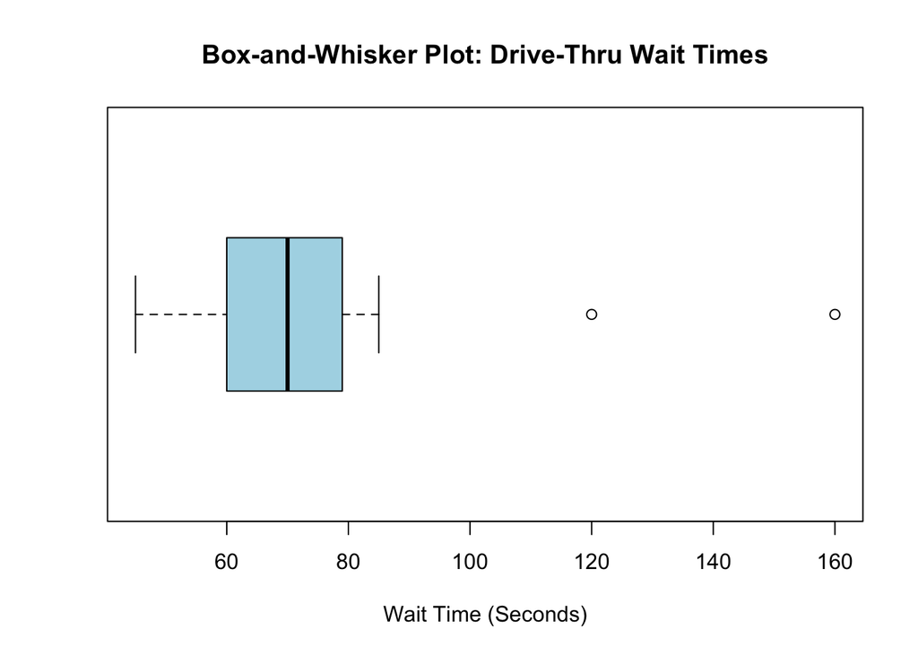

```r
boxplot(wait_times, horizontal = TRUE, col = "lightblue",
        xlab = "Wait Time (Seconds)", main = "Box-and-Whisker Plot: Drive-Thru Wait Times")
```

```r
outlier_comparison <- data.frame(
  Method = c("Classic z-Score Rule (|z| >= 2)", "Tukey Boxplot Rule (Upper Inner Fence)"),
  Test_Metric = c(sprintf("Max |z| = %.3f", max(z_mask)),
                  sprintf("Upper Fence = %.1f", upper_inner_fence_m)),
  Outliers_Identified = c(
    paste(wilcox_masking_data[z_mask >= 2], collapse = ", "),
    paste(wilcox_masking_data[wilcox_masking_data > upper_inner_fence_m], collapse = ", ")
  )
)
outlier_comparison$Outliers_Identified[outlier_comparison$Outliers_Identified == ""] <- "None (Masked)"

print(outlier_comparison)
```

```
##                                   Method           Test_Metric
## 1        Classic z-Score Rule (|z| >= 2)       Max |z| = 1.897
## 2 Tukey Boxplot Rule (Upper Inner Fence) Upper Fence = 62503.4
##   Outliers_Identified
## 1       None (Masked)
## 2        1e+05, 1e+05
```

## 3.5 Measures of Association: Pearson’s Correlation Coefficient

Measures of association describe the direction and strength of linear covariation between two numeric variables.

- **Sample Covariance ($s_{xy}$):** Measures average joint deviation from sample means:

$$s_{xy} = \frac{\sum_{i=1}^n (x_i -
\bar{x})(y_i - \bar{y})}{n - 1}$$

- **Pearson Product-Moment Correlation Coefficient ($r$):** Standardizes covariance into a scale-independent index of linear association:

$$r = \frac{s_{xy}}{s_x s_y} =
\frac{\sum_{i=1}^n (x_i - \bar{x})(y_i - \bar{y})}{\sqrt{\sum_{i=1}^n
(x_i - \bar{x})^2} \sqrt{\sum_{i=1}^n (y_i - \bar{y})^2}}$$

- **Properties and Limitations:**
  - Bounded: $-1.00 \le r \le +1.00$.
  - Direction: Positive indicates direct co-movement; negative indicates inverse co-movement.
  - Evaluates linear relationships exclusively; non-linear associations can yield $r \approx 0$. Correlation does not establish causation.

```r
ad_spend <- c(2, 4, 5, 6, 8, 11)
foot_traffic <- c(7, 9, 10, 13, 15, 20)

s_xy <- sum((ad_spend - mean(ad_spend)) * (foot_traffic - mean(foot_traffic))) / (length(ad_spend) - 1)
r_manual <- s_xy / (sd(ad_spend) * sd(foot_traffic))
print(sprintf("Sample Covariance s_xy = %.4f (cov = %.4f) | Manual r = %.4f",
              s_xy, cov(ad_spend, foot_traffic), r_manual))
```

```
## [1] "Sample Covariance s_xy = 14.8000 (cov = 14.8000) | Manual r = 0.9918"
```

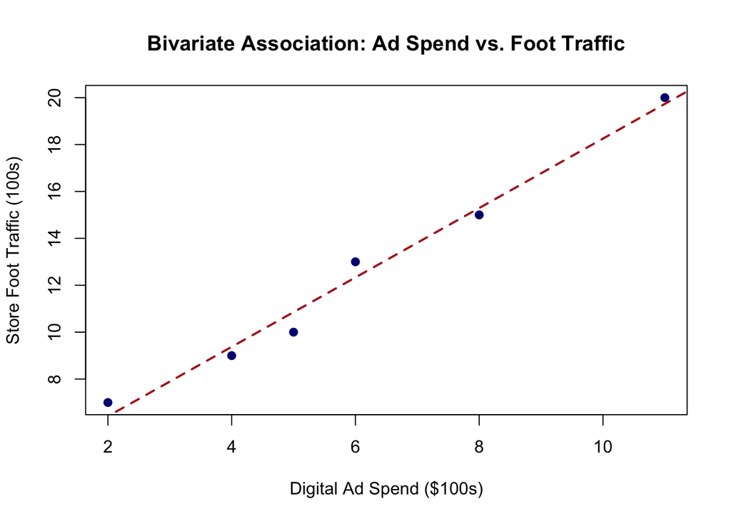

```r
cor_result <- cor.test(ad_spend, foot_traffic)

plot(ad_spend, foot_traffic, pch = 19, col = "navy",
     xlab = "Digital Ad Spend ($100s)", ylab = "Store Foot Traffic (100s)",
     main = "Bivariate Association: Ad Spend vs. Foot Traffic")
abline(lm(foot_traffic ~ ad_spend), col = "firebrick", lwd = 2, lty = 2)
```

```r
cor_summary <- data.frame(
  Sample_r = round(cor_result$estimate, 4),
  t_Statistic = round(cor_result$statistic, 4),
  df = cor_result$parameter,
  p_Value = round(cor_result$p.value, 4),
  CI_Lower = round(cor_result$conf.int[1], 4),
  CI_Upper = round(cor_result$conf.int[2], 4)
)

print(cor_summary)
```

```
##     Sample_r t_Statistic df p_Value CI_Lower CI_Upper
## cor   0.9918     15.5431  4   1e-04   0.9241   0.9991
```